# Question

Carlos está asistiendo a una clase de inglés y debe presentar cuatro evaluaciones que tienen calificaciones desde 1 hasta 100. La siguiente tabla muestra la nota de las tres evaluaciones que Carlos ha presentado hasta el momento:

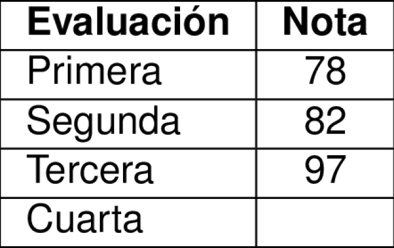

Si Carlos aspira a obtener una nota promedio de 80, ¿cuál debe ser su nota en la cuarta evaluación?

## Answerlist

- 63
- 68
- 58
- 73
- 53

# Solution

La respuesta correcta es 63.

Explicación paso a paso:

1. Primero, sumamos las notas de las tres evaluaciones presentadas:
   - Primera evaluación: 78
   - Segunda evaluación: 82
   - Tercera evaluación: 97
   - Suma total: 257
2. Como queremos un promedio de 80 en las cuatro evaluaciones:
   - Multiplicamos el promedio deseado por el número total de evaluaciones:
   - 80 × 4 = 320
3. Para encontrar la nota necesaria en la cuarta evaluación:
   - Restamos la suma de las tres primeras evaluaciones del total necesario:
   - 320 - 257 = 63

Por lo tanto, Carlos necesita obtener una nota de 63 en la cuarta evaluación para alcanzar un promedio de 80.

# Meta-information

exname: Promedio de Evaluaciones con Tabla extype: schoice exsolution: 10000 exshuffle: 5